# Hands-on I

Marta Sotelo (marta.sotelo01@estudiant.upf.edu)

Last update: `03/03/2026`

This practical focuses on data wrangling, exploratory data analysis, visualization, and critical comparison with published results using real biomedical data.

We will work with the publication [**Proteomic and Metabolomic Characterization of COVID-19 Patient Sera**](https://www.sciencedirect.com/science/article/pii/S0092867420306279)

# Exercise 1

Download and load Supplementary Table 1 (“Additional Demographical and Baseline Characteristics of COVID-19 Patients and Control Groups”) from the supplementary materials of the publication.

### Exercise 1.1

Reproduce Table 1 from the manuscript using the supplementary data. Match the reported summary statistics as closely as possible.

Briefly discuss any discrepancies between your results and the published table, and provide possible explanations.

```r
### Libraries
library(dplyr)
library(readxl)
library(Hmisc)
library(table1)
library(stringr)
library(ggplot2)
library(tidyr)
library(patchwork)
library(ggpubr)
library(table1)
library(grid)
library(pheatmap)
library(dplyr)
library(RColorBrewer)
```

```r
### Read the data
data <- readxl::read_xlsx("data/raw_data/table.xlsx", sheet = 2)
```

```r
names(data) <- str_replace_all(names(data), " ", "_")
names(data)[names(data) == "Age_(year)"] <- "Age_year"

data_f <- subset(data, select = c(Sex_g, Age_year, BMI_h, Admission_date, Onset_date_f,
                                 Date_of_progression_to_severe_state, Group_d))


### Function to convert the dates (manage Excel numeric dates and NA)
convert_date <- function(x) {

  if (inherits(x, "Date")) return(x)
  if (inherits(x, "POSIXt")) return(as.Date(x))

  x <- as.character(x)
  x[x %in% c("/", "", "NA")] <- NA

  out <- as.Date(rep(NA, length(x)))
  is_excel <- grepl("^\\d+$", x)

  out[is_excel] <- as.Date(
    as.numeric(x[is_excel]),
    origin = "1899-12-30"
  )

  return(out)
}

### Convert the dates using original column names
data_f <- data_f %>%
  mutate(
    Admission_date = convert_date(Admission_date),
    Onset_date     = convert_date(Onset_date_f),
    Severe_date    = convert_date(Date_of_progression_to_severe_state)
  )

#State development since the admission date
data_f$Development <- as.integer(
  difftime(
    data_f$Admission_date,
    data_f$Onset_date_f,
    units = "days"
  )
)

data_f$Time_admission_to_severe <- as.integer(
  difftime(
    data_f$Severe_date,
    data_f$Admission_date,
    units = "days"
  )
)

### Time variables (use absolute difference to avoid negatives)

data_f <- data_f %>%
  mutate(
    Development = abs(Development),
    Time_admission_to_severe = abs(Time_admission_to_severe)
  )

#Setting all the non-severe cases to NA
data_f$Time_admission_to_severe[data_f$Group_d != 3] <- NA


### Factor and numeric conversions
data_f <- data_f %>%
  mutate(
    Sex_g = factor(Sex_g, levels = c(1, 0), labels = c("Male", "Female")),
    Group_d = factor(Group_d,
                     levels = c(0, 1, 2, 3),
                     labels = c("Healthy", "Non-COVID", "Non-Severe", "Severe")),
    Age_year = as.numeric(Age_year),
    BMI_h = as.numeric(BMI_h)
  )


### Labels and units
label(data_f$Sex_g) <- "Sex"
label(data_f$Age_year) <- "Age"
label(data_f$BMI_h) <- "BMI"
label(data_f$Development) <- "Days from onset to admission"
label(data_f$Time_admission_to_severe) <- "Admission to severe state"

units(data_f$Age_year) <- "years"
units(data_f$BMI_h) <- "kg/m²"
units(data_f$Development) <- "days"
units(data_f$Time_admission_to_severe) <- "days"


### Adding a column with covid status

data_f <- data_f %>%
  mutate(
    COVID_status = case_when(
      Group_d %in% c("Non-Severe", "Severe") ~ "COVID",
      Group_d %in% c("Healthy", "Non-COVID") ~ "Non-COVID",
      TRUE ~ NA_character_
    )
  )
data_f$COVID_status <-factor(data_f$COVID_status, levels = c("COVID", "Non-COVID"), labels = c("COVID-19", ""))

#-------------------------------
### Creation of Table 1
table1(
  ~ Sex_g + Age_year + BMI_h + Development + Time_admission_to_severe | COVID_status * Group_d ,
  data = data_f,
  overall = FALSE,
  caption = "Table 1. Additional Demographical and Baseline Characteristics of COVID-19 Patients and Control Groups",
  render.missing = function(x)"",
)
```

Table 1. Additional Demographical and Baseline Characteristics of COVID-19 Patients and Control Groups

|  | COVID-19 Non-Severe (N=37) | COVID-19 Severe (N=28) | Healthy (N=28) | Non-COVID (N=25) |
| --- | --- | --- | --- | --- |
| Sex |  |  |  |  |
| Male | 23 (62.2%) | 16 (57.1%) | 21 (75.0%) | 17 (68.0%) |
| Female | 14 (37.8%) | 12 (42.9%) | 7 (25.0%) | 8 (32.0%) |
| Age (years) |  |  |  |  |
| Mean (SD) | 42.9 (12.5) | 54.8 (12.8) | 44.4 (8.26) | 49.2 (14.0) |
| Median [Min, Max] | 43.0 [18.0, 70.0] | 55.0 [30.0, 77.0] | 45.0 [28.0, 57.0] | 53.0 [23.0, 67.0] |
| BMI (kg/m²) |  |  |  |  |
| Mean (SD) | 24.5 (3.21) | 25.5 (2.52) | 24.4 (2.71) | 23.5 (2.68) |
| Median [Min, Max] | 24.2 [18.9, 30.7] | 24.9 [21.1, 31.3] | 24.2 [19.9, 32.9] | 24.7 [19.1, 27.4] |
| Days from onset to admission (days) |  |  |  |  |
| Mean (SD) | 3.59 (3.17) | 6.86 (5.17) | NA (NA) | NA (NA) |
| Median [Min, Max] | 3.00 [0, 14.0] | 7.50 [0, 23.0] | NA [NA, NA] | NA [NA, NA] |
| Admission to severe state (days) |  |  |  |  |
| Mean (SD) | NA (NA) | 1.46 (1.60) | NA (NA) | NA (NA) |
| Median [Min, Max] | NA [NA, NA] | 1.00 [0, 6.00] | NA [NA, NA] | NA [NA, NA] |

**About the data:**

- Based on what we have seen with our analysis, it is not possible to obtain the same results observed in the table 1 published on the study. This indicates that some data manipulation has been carried out by the researchers, an alteration that is not shared on the data analysis explanation. For instance, the variable called *Admission to severe state (days)* does not match the ones published on the article. In addition, the modification done in the dates of the patients is not stated in any part of the study, making impossible to achieve the same outcomes.

### Exercise 1.2

Perform an exploratory data analysis (EDA) of the dataset. At a minimum, include:

- Descriptive statistics for key variables
- Appropriate visualizations (e.g. distributions, group comparisons)
- A brief written summary of notable patterns, anomalies, or data quality issues

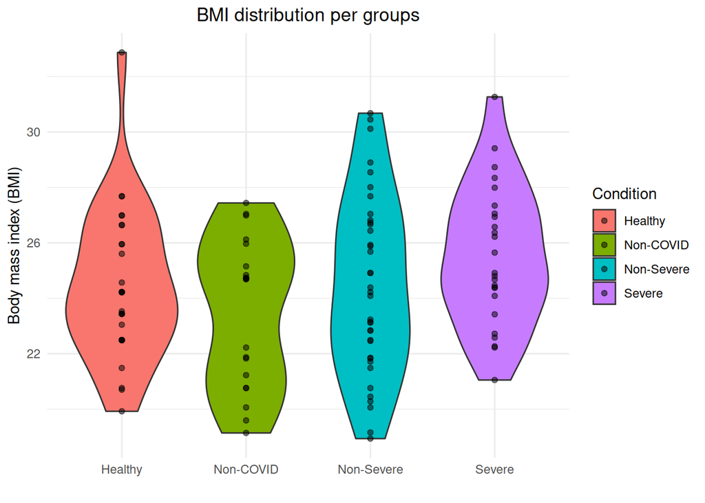

```r
g_bmi <- data_f %>%
  ggplot(mapping = aes(Group_d, BMI_h, fill = Group_d))+
  geom_violin()+
  geom_point(alpha = 0.5)+
  ggtitle("BMI distribution per groups")+
  labs(
    y = "Body mass index (BMI)",
    x = "",
    fill = "Condition"
  )+
  theme_minimal()+
  theme(plot.title = element_text(hjust = 0.5))

g_bmi
```

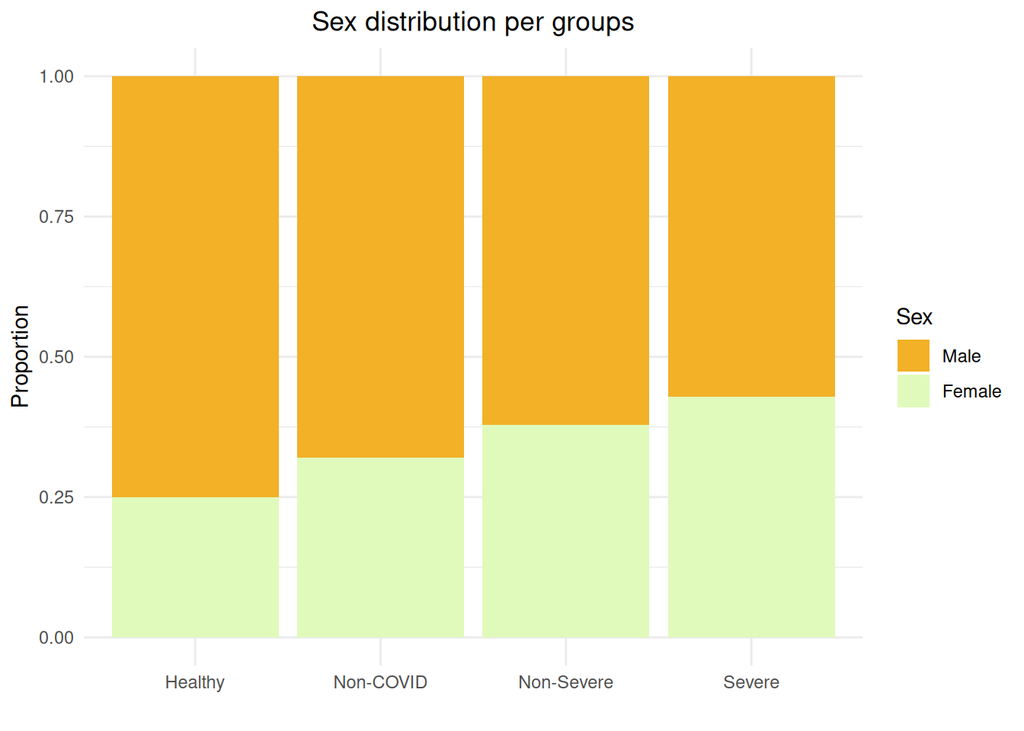

```r
ggsave("data/processed_data//BMI_Distribution.png", plot = g_bmi, width = 15, height = 12, dpi = 300)


g_sex <- data_f %>%
  ggplot(aes(x = Group_d, fill = Sex_g)) +
  geom_bar(position = "fill") +
  labs(
    title = "Sex distribution per groups",
    x = "",
    y = "Proportion",
    fill = "Sex"
  ) +
  scale_fill_manual(values = c("#F2B127", "#E0FABB")) +
  theme_minimal() +
  theme(plot.title = element_text(hjust = 0.5))

g_sex
```

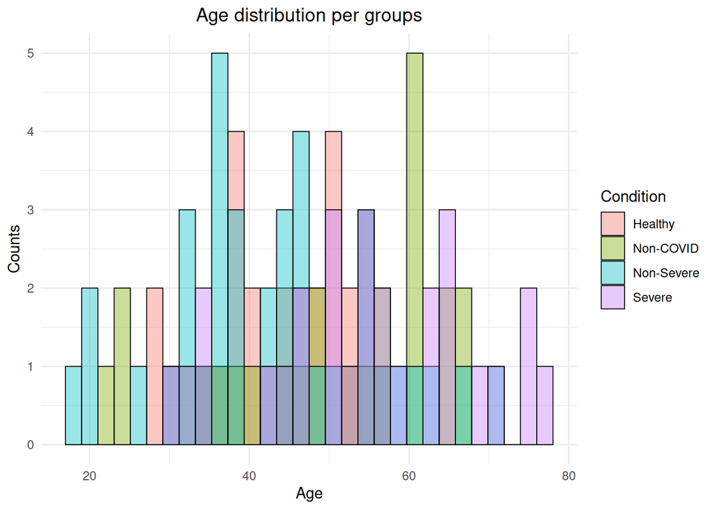

```r
ggsave("data/processed_data/Sex_Distribution.png", plot = g_sex, width = 15, height = 12, dpi = 300)


g_age <- data_f %>%
 ggplot(mapping = aes(x = Age_year, fill = Group_d)) +
  geom_histogram(
    bins = 30,
    position = "identity",
    alpha = 0.4,
    color = "black",
    linewidth = 0.3
  ) +
  ggtitle("Age distribution per groups")+
  labs(
    y = "Counts",
    fill = "Condition"
  )+
  theme_minimal()+
  theme(plot.title = element_text(hjust = 0.5))

g_age
```

```r
ggsave("data/processed_data//Age_Distribution.png", plot = g_age, width = 15, height = 12, dpi = 300)
```

**Summary:**

-**Sex**: As we move from “Healthy” to “Severe”, the proportion of women (light green) increases and the proportion of men (orange) decreases, but it does not a pattern that affect the results.

# Exercise 2

### Exercise 2.1

Reproduce Supplementary Figure 1 using the data without modifying or removing any observations. Use the same variables and groupings as in the original figure.

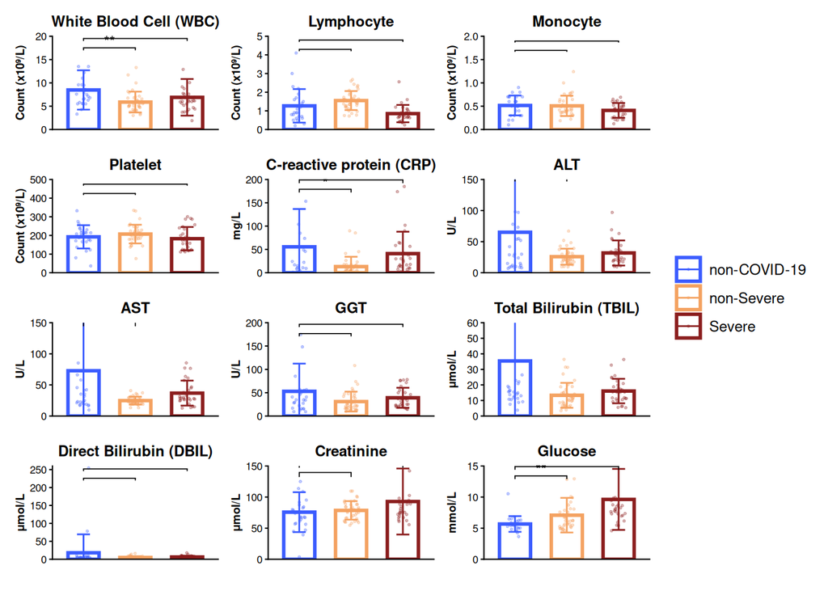

```r
### Variable selection
cols_lab <- names(data)[grep("WBC|Lymphocyte|Monocyte|Platelet|CRP|ALT|AST|GGT|TBIL|DBIL|Creatinine|Glucose", names(data))]

data_plot <- data %>%
  select(Group_d, all_of(cols_lab)) %>%
  mutate(across(all_of(cols_lab), ~ as.numeric(gsub("[^0-9.-]", "", as.character(.x))))) %>%
  pivot_longer(cols = -Group_d, names_to = "Variable", values_to = "Value") %>%
  mutate(
    Group_d = factor(
      Group_d,
      levels = c(1, 2, 3),
      labels = c("non-COVID-19", "non-Severe", "Severe") #Same labels
    )
  ) %>%
  filter(!is.na(Value), !is.na(Group_d))

### Statistical comparisons

mis_comparaciones <- list(
  c("non-COVID-19", "non-Severe"),
  c("non-COVID-19", "Severe")
)

### Label/Unit correction

config_variables <- list(
  "WBC_count,_×109/L" = list(title = "White Blood Cell (WBC)", unit = "Count (x10⁹/L)", lim = c(0, 20)),
  "Lymphocyte_count,_×109/L" = list(title = "Lymphocyte", unit = "Count (x10⁹/L)", lim = c(0, 5)),
  "Monocyte_count,_×109/L" = list(title = "Monocyte", unit = "Count (x10⁹/L)", lim = c(0, 2)),
  "Platelet_count,_×109/L" = list(title = "Platelet", unit = "Count (x10⁹/L)", lim = c(0, 500)),
  "CRP_i,_mg/L" = list(title = "C-reactive protein (CRP)", unit = "mg/L", lim = c(0, 200)),
  "ALT_j,__U/L" = list(title = "ALT", unit = "U/L", lim = c(0, 150)),
  "AST_k,_U/L" = list(title = "AST", unit = "U/L", lim = c(0, 150)),
  "GGT_l,_U/L" = list(title = "GGT", unit = "U/L", lim = c(0, 200)),
  "TBIL_m,_μmol/L" = list(title = "Total Bilirubin (TBIL)", unit = "μmol/L", lim = c(0, 60)),
  "DBIL_n,_μmol/L" = list(title = "Direct Bilirubin (DBIL)", unit = "μmol/L", lim = c(0, 260)),
  "Creatinine,_μmol/L" = list(title = "Creatinine", unit = "μmol/L", lim = c(0, 150)),
  "Glucose,_mmol/L" = list(title = "Glucose", unit = "mmol/L", lim = c(0, 15))
)

group_colors <- c("non-COVID-19" = "#3b5cff", "non-Severe" = "#f4a261", "Severe" = "#8b1e1e")

make_plot <- function(var_id) {
  conf <- config_variables[[var_id]]
  df_sub <- data_plot %>% dplyr::filter(Variable == var_id)

  # Key position
  y_pos_stars <- c(conf$lim[2] * 0.82, conf$lim[2] * 0.92)

  ggplot(df_sub, aes(x = Group_d, y = Value, color = Group_d)) +

    stat_summary(
      fun = mean,
      geom = "bar",
      width = 0.6,
      aes(color = Group_d),
      fill = NA,
      linewidth = 1
    ) +
    stat_summary(
      fun.data = mean_sdl,
      fun.args = list(mult = 1),
      geom = "errorbar",
      width = 0.25,
      linewidth = 0.5,
      aes(color = Group_d)
    ) +

    geom_jitter(
      aes(color = Group_d),
      width = 0.15,
      size = 0.5,
      alpha = 0.3
    ) +

    scale_color_manual(
  values = group_colors,
  name = NULL ) +

    ### STATS
    stat_compare_means(
      comparisons = mis_comparaciones,
      label = "p.signif",
      method = "t.test",
      method.args = list(var.equal = FALSE),
      hide.ns = TRUE,
      label.y = y_pos_stars,
      size = 3.2,
      tip.length = 0.02
    ) +

    coord_cartesian(ylim = conf$lim) +
    scale_y_continuous(expand = c(0, 0), breaks = scales::pretty_breaks(n = 5)) +

    ### Labels & theme
    labs(title = conf$title, y = conf$unit, x = "") +
    theme_classic(base_size = 8) +
    theme(
      legend.position = "none",
      plot.title = element_text(face = "bold", hjust = 0.5, size = 9),
      axis.title.y = element_text(face = "bold", size = 7),
      axis.text.x = element_blank(),
      axis.ticks.x = element_blank()
    )
}


### Plot list
plots <- lapply(names(config_variables), make_plot)

### Collecting the plots
final_plot <- wrap_plots(plots, ncol = 3) +
  plot_layout(guides = "collect") &
  theme(
    legend.position = "right",
    legend.title = element_blank(),
    legend.text = element_text(size = 9)
  )

final_plot
```

```r
### PLOT EXPORTING: Dimension that ensure correct visualization
ggsave("data/processed_data//Supplementary_Figure_1.png", plot = final_plot, width = 10, height = 16, dpi = 300)
```

### Exercise 2.2

Identify and handle outliers using an appropriate and well-justified method (e.g. removal, transformation, or robust statistics).

Reproduce Supplementary Figure 1 after outlier handling and discuss how and why the results change.

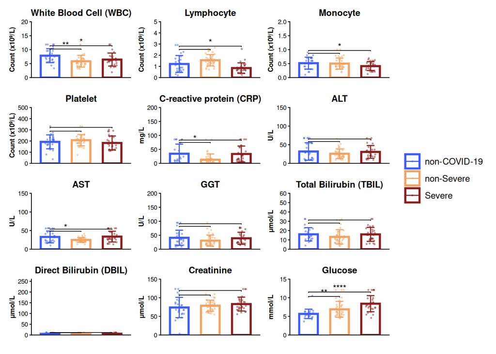

```r
### Limiting maximum Tukey values (Q3 + 1.5*IQR)
handle_outliers <- function(x) {
  if(all(is.na(x))) return(x)
  qnt <- quantile(x, probs = c(0.25, 0.75), na.rm = TRUE)
  iqr <- qnt[2] - qnt[1]
  limite_superior <- qnt[2] + 1.5 * iqr
  x[x > limite_superior] <- limite_superior  # Limitiing greater values
  return(x)
}

### Apply the function to each variable
data_plot_clean <- data_plot %>%
  group_by(Variable) %>%
  mutate(Value = handle_outliers(Value)) %>%
  ungroup()

make_plot_clean <- function(var_id) {
  conf <- config_variables[[var_id]]
  df_sub <- data_plot_clean %>% filter(Variable == var_id)

  ### Positions for significant keys
  y_max <- max(df_sub$Value, na.rm = TRUE)
  y_pos_stars <- c(y_max * 0.82, y_max * 0.92)

  ggplot(df_sub, aes(x = Group_d, y = Value)) +

    ### Bars
    stat_summary(
      fun = mean,
      geom = "bar",
      width = 0.6,
      aes(color = Group_d),
      fill = NA,
      linewidth = 1
    ) +

    ### Error bars
    stat_summary(
      fun.data = mean_sdl,
      fun.args = list(mult = 1),
      geom = "errorbar",
      width = 0.25,
      linewidth = 0.5,
      aes(color = Group_d)
    ) +

    ### Winsorizades dots
    geom_jitter(
      aes(color = Group_d),
      width = 0.15,
      size = 0.5,
      alpha = 0.4
    ) +

    scale_color_manual(values = group_colors, name = NULL) +

    ### Welch t-test
    stat_compare_means(
      comparisons = mis_comparaciones,
      label = "p.signif",
      method = "t.test",
      method.args = list(var.equal = FALSE),
      hide.ns = TRUE,
      label.y = y_pos_stars,
      size = 3.2,
      tip.length = 0.02
    ) +

    coord_cartesian(ylim = conf$lim) +
    scale_y_continuous(expand = c(0,0), breaks = scales::pretty_breaks(n = 5)) +

    labs(title = conf$title, y = conf$unit, x = "") +
    theme_classic(base_size = 8) +
    theme(
      legend.position = "none",
      plot.title = element_text(face = "bold", hjust = 0.5, size = 9),
      axis.title.y = element_text(face = "bold", size = 7),
      axis.text.x = element_blank(),
      axis.ticks.x = element_blank()
    )
}

plots_clean <- lapply(names(config_variables), make_plot_clean)

figura_2_clean <- wrap_plots(plots_clean, ncol = 3) +
  plot_layout(guides = "collect") &
  theme(
    legend.position = "right",
    legend.title = element_blank(),
    legend.text = element_text(size = 9)
  )

figura_2_clean
```

```r
### PLOT EXPORTING: Dimension that ensure correct visualization
ggsave("data/processed_data//Supplementary_Figure_1_Winsorized.png",
       plot = figura_2_clean,
       width = 10, height = 16, dpi = 300)
```

# Exercise 3

Create a heatmap of the biomarker data. Include group and gender as annotation variables.

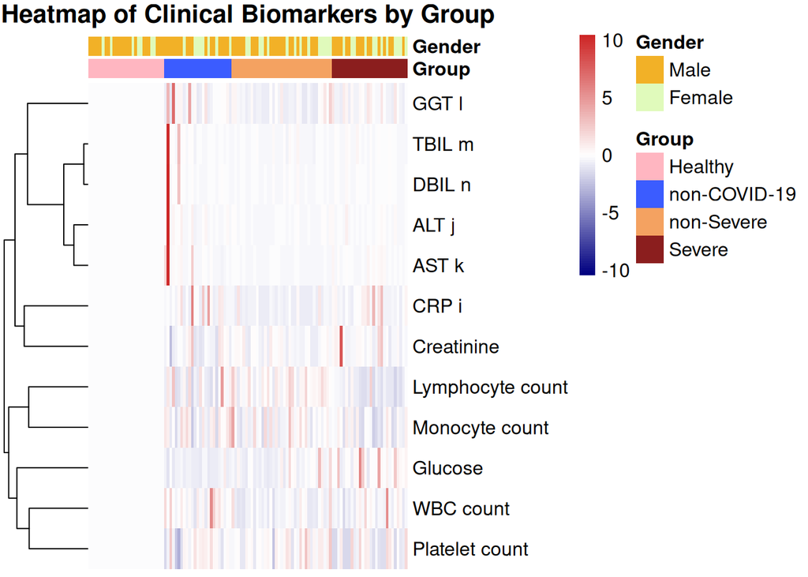

```r
data_heatmap <- data %>%
  select(all_of(cols_lab), Group_d, Sex_g) %>%
  arrange(Group_d) # Arranging by group

### Marker matrix
biomarkers <- data_heatmap %>%
  select(all_of(cols_lab)) %>%
  mutate(across(everything(), ~ as.numeric(gsub("[^0-9.-]", "", as.character(.))))) %>%
  as.matrix()


### NA imputing using average

for(i in 1:ncol(biomarkers)){
  col_mean <- mean(biomarkers[, i], na.rm = TRUE)
  biomarkers[is.na(biomarkers[, i]), i] <- col_mean
}

### Col name adaptation for the plot
colnames(biomarkers) <- colnames(biomarkers) %>%
  str_replace_all("_", " ") %>%
  str_split(",") %>%
  sapply("[", 1)

### Labels
annotation <- data_heatmap %>%
  transmute(
    Group = factor(Group_d, levels = c(0, 1, 2, 3),
                   labels = c("Healthy", "non-COVID-19", "non-Severe", "Severe")),
    Gender = factor(Sex_g, levels = c(1, 0),
                    labels = c("Male", "Female"))
  ) %>%
  as.data.frame()

row.names(biomarkers) <- paste0("S_", 1:nrow(biomarkers))
row.names(annotation) <- row.names(biomarkers)

### Color palette
annotation_colors <- list(
  Group = c("Healthy" = "lightpink",
            "non-COVID-19" = "#3b5cff",
            "non-Severe"   = "#f4a261",
            "Severe"       = "#8b1e1e"),
  Gender = c("Male" = "#F2B127", "Female" = "#E0FABB")
)

### Heatmap color palette
heatmap_palette <- colorRampPalette(c("navy", "white", "firebrick3"))(100)

### HEATMAP

heatmap <- pheatmap(
  t(biomarkers),               ### transpose to obtain markers as rows
  scale = "row",               ### biomarker normalization (Z-score)
  clustering_distance_rows = "euclidean",
  clustering_method = "complete",
  cluster_rows = TRUE,
  cluster_cols = FALSE,
  annotation_col = annotation,
  annotation_colors = annotation_colors,
  color = heatmap_palette,
  border_color = NA,
  show_rownames = TRUE,
  show_colnames = FALSE,
  fontsize = 12,
  main = "Heatmap of Clinical Biomarkers by Group"
)
```

```r
ggsave("data/processed_data//HeatMap.png", plot = heatmap, width = 15, height = 12, dpi = 300, bg = "white")
```

# Conclusion

Write a concise conclusion (1 paragraphs) summarizing the main differences observed across the three patient groups based on the twelve clinical parameters. Support your statements with evidence from your analyses.

# session info

R version 4.3.3 (2024-02-29) Platform: x86_64-pc-linux-gnu (64-bit) Running under: Ubuntu 24.04.4 LTS

Matrix products: default BLAS: /usr/lib/x86_64-linux-gnu/blas/libblas.so.3.12.0 LAPACK: /usr/lib/x86_64-linux-gnu/lapack/liblapack.so.3.12.0

locale: [1] LC_CTYPE=en_US.UTF-8 LC_NUMERIC=C  
[3] LC_TIME=en_US.UTF-8 LC_COLLATE=en_US.UTF-8  
[5] LC_MONETARY=en_US.UTF-8 LC_MESSAGES=en_US.UTF-8  
[7] LC_PAPER=en_US.UTF-8 LC_NAME=C  
[9] LC_ADDRESS=C LC_TELEPHONE=C  
[11] LC_MEASUREMENT=en_US.UTF-8 LC_IDENTIFICATION=C

time zone: Europe/Madrid tzcode source: system (glibc)

attached base packages: [1] grid stats graphics grDevices utils datasets methods  
[8] base

other attached packages: [1] RColorBrewer_1.1-3 pheatmap_1.0.13 ggpubr_0.6.3 patchwork_1.3.2  
[5] tidyr_1.3.2 ggplot2_4.0.2 stringr_1.6.0 table1_1.5.1  
[9] Hmisc_5.2-5 readxl_1.4.5 dplyr_1.2.0

loaded via a namespace (and not attached): [1] gtable_0.3.6 xfun_0.57 bslib_0.10.0  
[4] htmlwidgets_1.6.4 rstatix_0.7.3 vctrs_0.7.2  
[7] tools_4.3.3 generics_0.1.4 tibble_3.3.1  
[10] cluster_2.1.8.2 pkgconfig_2.0.3 data.table_1.18.2.1 [13] checkmate_2.3.4 S7_0.2.1 lifecycle_1.0.5  
[16] compiler_4.3.3 farver_2.1.2 textshaping_1.0.5  
[19] carData_3.0-6 htmltools_0.5.9 sass_0.4.10  
[22] yaml_2.3.12 htmlTable_2.4.3 Formula_1.2-5  
[25] pillar_1.11.1 car_3.1-5 jquerylib_0.1.4  
[28] cachem_1.1.0 rpart_4.1.23 abind_1.4-8  
[31] tidyselect_1.2.1 digest_0.6.39 stringi_1.8.7  
[34] purrr_1.2.1 labeling_0.4.3 fastmap_1.2.0  
[37] colorspace_2.1-2 cli_3.6.5 magrittr_2.0.4  
[40] base64enc_0.1-6 broom_1.0.12 foreign_0.8-86  
[43] withr_3.0.2 scales_1.4.0 backports_1.5.0  
[46] rmarkdown_2.31 otel_0.2.0 nnet_7.3-19  
[49] gridExtra_2.3 ggsignif_0.6.4 cellranger_1.1.0  
[52] ragg_1.5.2 evaluate_1.0.5 knitr_1.51  
[55] rlang_1.1.7 glue_1.8.0 rstudioapi_0.18.0  
[58] jsonlite_2.0.0 R6_2.6.1 systemfonts_1.3.2